# Final Exam ADMN 872: Predictive Analytics

The Data:

- Read your data in R and call it df. For the rest of this document `y` refers to the variable you are predicting.

```r
library(gridExtra)
```

```r
library(ggplot2)
library(ggfortify)
library(kableExtra)
library(car)
library(lattice)
library(ggvis)
library(MASS)
library(ISLR)
library(class)
library(magrittr)
library(ggvis)
library(boot)
library(leaps)
library(glmnet)
library(pls)
library(readr)
library(dplyr)
df <- read_csv("C:/Users/bbutella/Desktop/Predictive Analytics/Final Project/output/2023.csv")
head(df)
```

```
## # A tibble: 6 × 33
##   FL_DATE    AIRLINE_CODE DOT_CODE FL_NUMBER ORIGIN ORIGIN_CITY  DEST  DEST_CITY
##   <date>     <chr>           <dbl>     <dbl> <chr>  <chr>        <chr> <chr>
## 1 2023-06-04 9E              20363      4628 DSM    Des Moines,… LGA   New York…
## 2 2023-06-01 9E              20363      4628 ROC    Rochester, … LGA   New York…
## 3 2023-06-02 9E              20363      4628 ROC    Rochester, … LGA   New York…
## 4 2023-06-01 9E              20363      4629 ITH    Ithaca/Cort… JFK   New York…
## 5 2023-06-02 9E              20363      4629 ITH    Ithaca/Cort… JFK   New York…
## 6 2023-06-03 9E              20363      4629 ITH    Ithaca/Cort… JFK   New York…
## # ℹ 25 more variables: CRS_DEP_TIME <dbl>, DEP_TIME <dbl>, DEP_DELAY <dbl>,
## #   TAXI_OUT <dbl>, WHEELS_OFF <dbl>, WHEELS_ON <dbl>, TAXI_IN <dbl>,
## #   CRS_ARR_TIME <dbl>, ARR_TIME <dbl>, ARR_DELAY <dbl>, CANCELLED <dbl>,
## #   CANCELLATION_CODE <chr>, DIVERTED <dbl>, CRS_ELAPSED_TIME <dbl>,
## #   ELAPSED_TIME <dbl>, AIR_TIME <dbl>, DISTANCE <dbl>,
## #   DELAY_DUE_CARRIER <dbl>, DELAY_DUE_WEATHER <dbl>, DELAY_DUE_NAS <dbl>,
## #   DELAY_DUE_SECURITY <dbl>, DELAY_DUE_LATE_AIRCRAFT <dbl>, FL_YEAR <dbl>, …
```

```r
#find top 3 airlines to work with, instead of full data set due to eliminate length

Airlines <- df %>%
  group_by(AIRLINE_CODE) %>%
  summarize(count = n()) %>%
  arrange(desc(count)) %>%
  head(3)

print(Airlines)
```

```
## # A tibble: 3 × 2
##   AIRLINE_CODE  count
##   <chr>         <int>
## 1 WN           941733
## 2 DL           656543
## 3 AA           630400
```

```r
airline_mapping <- data.frame(
  AIRLINE_CODE = c("WN", "DL", "AA") ,
  full_name = c("Southwest Airlines", "Delta Air Lines", "American Airlines"))



df1 <- df %>%
  left_join(airline_mapping, by = "AIRLINE_CODE") %>%
  mutate(Full_Name_AIR = coalesce(full_name, as.character(AIRLINE_CODE)))

head(df1)
```

```
## # A tibble: 6 × 35
##   FL_DATE    AIRLINE_CODE DOT_CODE FL_NUMBER ORIGIN ORIGIN_CITY  DEST  DEST_CITY
##   <date>     <chr>           <dbl>     <dbl> <chr>  <chr>        <chr> <chr>
## 1 2023-06-04 9E              20363      4628 DSM    Des Moines,… LGA   New York…
## 2 2023-06-01 9E              20363      4628 ROC    Rochester, … LGA   New York…
## 3 2023-06-02 9E              20363      4628 ROC    Rochester, … LGA   New York…
## 4 2023-06-01 9E              20363      4629 ITH    Ithaca/Cort… JFK   New York…
## 5 2023-06-02 9E              20363      4629 ITH    Ithaca/Cort… JFK   New York…
## 6 2023-06-03 9E              20363      4629 ITH    Ithaca/Cort… JFK   New York…
## # ℹ 27 more variables: CRS_DEP_TIME <dbl>, DEP_TIME <dbl>, DEP_DELAY <dbl>,
## #   TAXI_OUT <dbl>, WHEELS_OFF <dbl>, WHEELS_ON <dbl>, TAXI_IN <dbl>,
## #   CRS_ARR_TIME <dbl>, ARR_TIME <dbl>, ARR_DELAY <dbl>, CANCELLED <dbl>,
## #   CANCELLATION_CODE <chr>, DIVERTED <dbl>, CRS_ELAPSED_TIME <dbl>,
## #   ELAPSED_TIME <dbl>, AIR_TIME <dbl>, DISTANCE <dbl>,
## #   DELAY_DUE_CARRIER <dbl>, DELAY_DUE_WEATHER <dbl>, DELAY_DUE_NAS <dbl>,
## #   DELAY_DUE_SECURITY <dbl>, DELAY_DUE_LATE_AIRCRAFT <dbl>, FL_YEAR <dbl>, …
```

```r
df_filtered <- df1 %>%
  filter(AIRLINE_CODE %in% Airlines$AIRLINE_CODE)

# View the filtered data frame
head(df_filtered)
```

```
## # A tibble: 6 × 35
##   FL_DATE    AIRLINE_CODE DOT_CODE FL_NUMBER ORIGIN ORIGIN_CITY  DEST  DEST_CITY
##   <date>     <chr>           <dbl>     <dbl> <chr>  <chr>        <chr> <chr>
## 1 2023-06-01 AA              19805         1 JFK    New York, NY LAX   Los Ange…
## 2 2023-06-02 AA              19805         1 JFK    New York, NY LAX   Los Ange…
## 3 2023-06-03 AA              19805         1 JFK    New York, NY LAX   Los Ange…
## 4 2023-06-04 AA              19805         1 JFK    New York, NY LAX   Los Ange…
## 5 2023-06-05 AA              19805         1 JFK    New York, NY LAX   Los Ange…
## 6 2023-06-06 AA              19805         1 JFK    New York, NY LAX   Los Ange…
## # ℹ 27 more variables: CRS_DEP_TIME <dbl>, DEP_TIME <dbl>, DEP_DELAY <dbl>,
## #   TAXI_OUT <dbl>, WHEELS_OFF <dbl>, WHEELS_ON <dbl>, TAXI_IN <dbl>,
## #   CRS_ARR_TIME <dbl>, ARR_TIME <dbl>, ARR_DELAY <dbl>, CANCELLED <dbl>,
## #   CANCELLATION_CODE <chr>, DIVERTED <dbl>, CRS_ELAPSED_TIME <dbl>,
## #   ELAPSED_TIME <dbl>, AIR_TIME <dbl>, DISTANCE <dbl>,
## #   DELAY_DUE_CARRIER <dbl>, DELAY_DUE_WEATHER <dbl>, DELAY_DUE_NAS <dbl>,
## #   DELAY_DUE_SECURITY <dbl>, DELAY_DUE_LATE_AIRCRAFT <dbl>, FL_YEAR <dbl>, …
```

```r
df2<-df_filtered[,1:34]
head(df2)
```

```
## # A tibble: 6 × 34
##   FL_DATE    AIRLINE_CODE DOT_CODE FL_NUMBER ORIGIN ORIGIN_CITY  DEST  DEST_CITY
##   <date>     <chr>           <dbl>     <dbl> <chr>  <chr>        <chr> <chr>
## 1 2023-06-01 AA              19805         1 JFK    New York, NY LAX   Los Ange…
## 2 2023-06-02 AA              19805         1 JFK    New York, NY LAX   Los Ange…
## 3 2023-06-03 AA              19805         1 JFK    New York, NY LAX   Los Ange…
## 4 2023-06-04 AA              19805         1 JFK    New York, NY LAX   Los Ange…
## 5 2023-06-05 AA              19805         1 JFK    New York, NY LAX   Los Ange…
## 6 2023-06-06 AA              19805         1 JFK    New York, NY LAX   Los Ange…
## # ℹ 26 more variables: CRS_DEP_TIME <dbl>, DEP_TIME <dbl>, DEP_DELAY <dbl>,
## #   TAXI_OUT <dbl>, WHEELS_OFF <dbl>, WHEELS_ON <dbl>, TAXI_IN <dbl>,
## #   CRS_ARR_TIME <dbl>, ARR_TIME <dbl>, ARR_DELAY <dbl>, CANCELLED <dbl>,
## #   CANCELLATION_CODE <chr>, DIVERTED <dbl>, CRS_ELAPSED_TIME <dbl>,
## #   ELAPSED_TIME <dbl>, AIR_TIME <dbl>, DISTANCE <dbl>,
## #   DELAY_DUE_CARRIER <dbl>, DELAY_DUE_WEATHER <dbl>, DELAY_DUE_NAS <dbl>,
## #   DELAY_DUE_SECURITY <dbl>, DELAY_DUE_LATE_AIRCRAFT <dbl>, FL_YEAR <dbl>, …
```

## Part 1: Exploratory Data Analysis (20 points)

1. Check for existence of NA’s (missing data) (Hint: check if the complete.case(df) has the same number of rows and the original df)

```r
#cleaning data
complete.cases(df2)
```

[output not shown]

[output cut: 8320 more lines]

```r
#NA's are known, in the delayed types column, i.e. late due to x or due to y and the amount of time delayed. Will clean the data below
```

2. Classify all categorical variables **except the one you are predicting** as factors. Calculate the summary statistics of the whole data set. Based on your results, do you believe your data would benefit from scaling?

```r
summary(df2)
```

```
##     FL_DATE           AIRLINE_CODE          DOT_CODE       FL_NUMBER
##  Min.   :2023-01-01   Length:2228676     Min.   :19393   Min.   :   1
##  1st Qu.:2023-03-07   Class :character   1st Qu.:19393   1st Qu.: 992
##  Median :2023-05-07   Mode  :character   Median :19790   Median :1725
##  Mean   :2023-05-05                      Mean   :19626   Mean   :1782
##  3rd Qu.:2023-07-05                      3rd Qu.:19805   3rd Qu.:2502
##  Max.   :2023-08-31                      Max.   :19805   Max.   :9887
##
##     ORIGIN          ORIGIN_CITY            DEST            DEST_CITY
##  Length:2228676     Length:2228676     Length:2228676     Length:2228676
##  Class :character   Class :character   Class :character   Class :character
##  Mode  :character   Mode  :character   Mode  :character   Mode  :character
##
##
##
##
##   CRS_DEP_TIME     DEP_TIME       DEP_DELAY          TAXI_OUT
##  Min.   :   1   Min.   :   1    Min.   : -59.00   Min.   :  1.00
##  1st Qu.: 900   1st Qu.: 900    1st Qu.:  -4.00   1st Qu.: 11.00
##  Median :1321   Median :1327    Median :   0.00   Median : 14.00
##  Mean   :1334   Mean   :1339    Mean   :  15.31   Mean   : 15.81
##  3rd Qu.:1755   3rd Qu.:1803    3rd Qu.:  14.00   3rd Qu.: 18.00
##  Max.   :2359   Max.   :2400    Max.   :4413.00   Max.   :222.00
##                 NA's   :29784   NA's   :29784     NA's   :30541
##    WHEELS_OFF      WHEELS_ON        TAXI_IN         CRS_ARR_TIME
##  Min.   :   1    Min.   :   1    Min.   :  1.000   Min.   :   1
##  1st Qu.: 914    1st Qu.:1023    1st Qu.:  4.000   1st Qu.:1045
##  Median :1338    Median :1452    Median :  6.000   Median :1510
##  Mean   :1358    Mean   :1445    Mean   :  7.456   Mean   :1477
##  3rd Qu.:1815    3rd Qu.:1920    3rd Qu.:  9.000   3rd Qu.:1930
##  Max.   :2400    Max.   :2400    Max.   :195.000   Max.   :2359
##  NA's   :30541   NA's   :31092   NA's   :31092
##     ARR_TIME       ARR_DELAY         CANCELLED       CANCELLATION_CODE
##  Min.   :   1    Min.   : -92.00   Min.   :0.00000   Length:2228676
##  1st Qu.:1025    1st Qu.: -13.00   1st Qu.:0.00000   Class :character
##  Median :1453    Median :  -4.00   Median :0.00000   Mode  :character
##  Mean   :1445    Mean   :   9.44   Mean   :0.01377
##  3rd Qu.:1923    3rd Qu.:  12.00   3rd Qu.:0.00000
##  Max.   :2400    Max.   :4405.00   Max.   :1.00000
##  NA's   :31092   NA's   :36500
```

[output cut: 17 more lines]

```
##  Min.   :  0.0      Min.   :   0.0          Min.   :2023   Length:2228676
##  1st Qu.:  0.0      1st Qu.:   0.0          1st Qu.:2023   Class :character
##  Median :  0.0      Median :  11.0          Median :2023   Mode  :character
##  Mean   :  0.1      Mean   :  30.5          Mean   :2023
##  3rd Qu.:  0.0      3rd Qu.:  35.0          3rd Qu.:2023
##  Max.   :808.0      Max.   :3581.0          Max.   :2023
##  NA's   :1720843    NA's   :1720843
##     FL_DAY           full_name
##  Length:2228676     Length:2228676
##  Class :character   Class :character
##  Mode  :character   Mode  :character
##
##
##
##
```

```r
#Yes, the data needs to be scaled. There are multiple dimensions in the data, and the scope of analytics will dictate what needs to be spliced and scaled back. We have provided the following scales to surface question pertaining to the data. Below we have Identified the top 3 airlines we want to view, Track trends based on a high level approach of on time performance (OTP %). Then the data is grouped by the date & airline code, for a time series vantage point.

#Chose to use a binary category. Per the definition found online, if the CSR, Computerized Reservation Systems is within 15mins of take off/landing than the flight is on time. For this project we will focuse on the Arrival time, Since more factors can effect the overall


#Binomial Mutated to DF, if ON TIME then 1 else Late = 0

df3<- df2%>%
  mutate(ontime = ifelse(df2$ARR_DELAY<=15 & df2$DIVERTED == 0 & df2$CANCELLED == 0,1,0))


#Had to clean up the null values, previous report, had if 0 then null.
df3$DELAY_DUE_CARRIER <- ifelse(is.na(df3$DELAY_DUE_CARRIER), 0, df3$DELAY_DUE_CARRIER)
df3$DELAY_DUE_WEATHER <- ifelse(is.na(df3$DELAY_DUE_WEATHER), 0, df3$DELAY_DUE_WEATHER)
df3$DELAY_DUE_NAS<- ifelse(is.na(df3$DELAY_DUE_NAS), 0, df3$DELAY_DUE_NAS)
df3$DELAY_DUE_SECURITY <- ifelse(is.na(df3$DELAY_DUE_SECURITY), 0, df3$DELAY_DUE_SECURITY)
df3$DELAY_DUE_LATE_AIRCRAFT<- ifelse(is.na(df3$DELAY_DUE_LATE_AIRCRAFT), 0, df3$DELAY_DUE_LATE_AIRCRAFT)



head(df3)
```

```
## # A tibble: 6 × 35
##   FL_DATE    AIRLINE_CODE DOT_CODE FL_NUMBER ORIGIN ORIGIN_CITY  DEST  DEST_CITY
##   <date>     <chr>           <dbl>     <dbl> <chr>  <chr>        <chr> <chr>
## 1 2023-06-01 AA              19805         1 JFK    New York, NY LAX   Los Ange…
## 2 2023-06-02 AA              19805         1 JFK    New York, NY LAX   Los Ange…
## 3 2023-06-03 AA              19805         1 JFK    New York, NY LAX   Los Ange…
## 4 2023-06-04 AA              19805         1 JFK    New York, NY LAX   Los Ange…
## 5 2023-06-05 AA              19805         1 JFK    New York, NY LAX   Los Ange…
## 6 2023-06-06 AA              19805         1 JFK    New York, NY LAX   Los Ange…
## # ℹ 27 more variables: CRS_DEP_TIME <dbl>, DEP_TIME <dbl>, DEP_DELAY <dbl>,
## #   TAXI_OUT <dbl>, WHEELS_OFF <dbl>, WHEELS_ON <dbl>, TAXI_IN <dbl>,
## #   CRS_ARR_TIME <dbl>, ARR_TIME <dbl>, ARR_DELAY <dbl>, CANCELLED <dbl>,
## #   CANCELLATION_CODE <chr>, DIVERTED <dbl>, CRS_ELAPSED_TIME <dbl>,
## #   ELAPSED_TIME <dbl>, AIR_TIME <dbl>, DISTANCE <dbl>,
## #   DELAY_DUE_CARRIER <dbl>, DELAY_DUE_WEATHER <dbl>, DELAY_DUE_NAS <dbl>,
## #   DELAY_DUE_SECURITY <dbl>, DELAY_DUE_LATE_AIRCRAFT <dbl>, FL_YEAR <dbl>, …
```

```r
#Provided this table to present high level view of on time & Late Data
Ontime_ct <- df3 %>%
  group_by(AIRLINE_CODE) %>%
  summarize(ON_TIME = sum(ontime==1, na.rm=TRUE),
               LATE = sum(ontime==0, na.rm=TRUE) )
  #print(Ontime_ct)

  #rm outliers in Arr_delay, the root of categorial numeric value for Ontime. starting with a 1 day delay. Time is formatted miltary time.
   removeontime<- subset(df3,df3$ontime == 1)
```

3. For the numerical variables, plot boxplots based on values of `y`. Do you see a difference between the boxplots for any of the variables you choose?

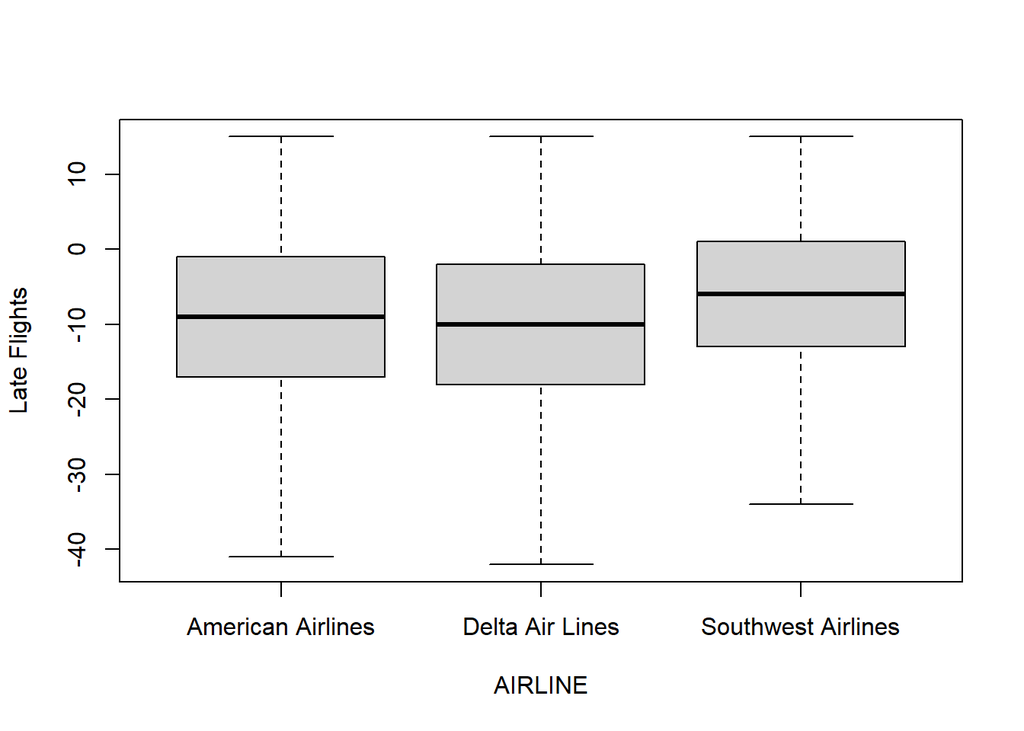

```r
#Outliers removed
bxplt <- boxplot(
  removeontime$ARR_DELAY ~ as.factor(removeontime$full_name),
  data = removeontime,
  ylab = "Late Flights",
  xlab = "AIRLINE",
  outline = FALSE
)
```

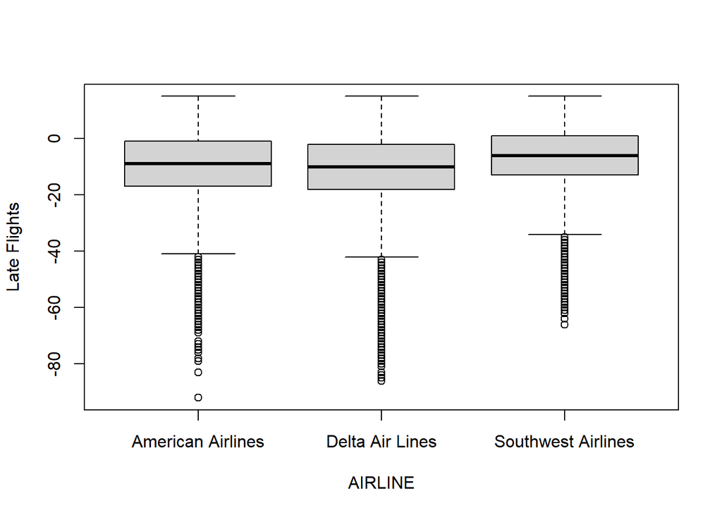

```r
#With outliers for high level view
bxpltwout <- boxplot(
  removeontime$ARR_DELAY ~ as.factor(removeontime$full_name),
  data = removeontime,
  ylab = "Late Flights",
  xlab = "AIRLINE"

)
```

```r
#bxplt
#bxpltwout

#time series lense for trends

# % of Flights not on time per month
df3$FL_DATE <- as.Date(df3$FL_DATE)

# Create a new variable FL_MONTH to represent the month
df3$FL_MONTH <- format(df3$FL_DATE, "%Y-%m")

# OTP means on time performance (%)
OTP <- df3 %>%
  group_by(FL_MONTH, AIRLINE_CODE) %>%
  summarize(
    OnTimeCount = sum(ontime == 1, na.rm = TRUE),
    TotalFlights = n()
  ) %>%
  mutate(OnTimePercent = (OnTimeCount / TotalFlights) * 100)
```

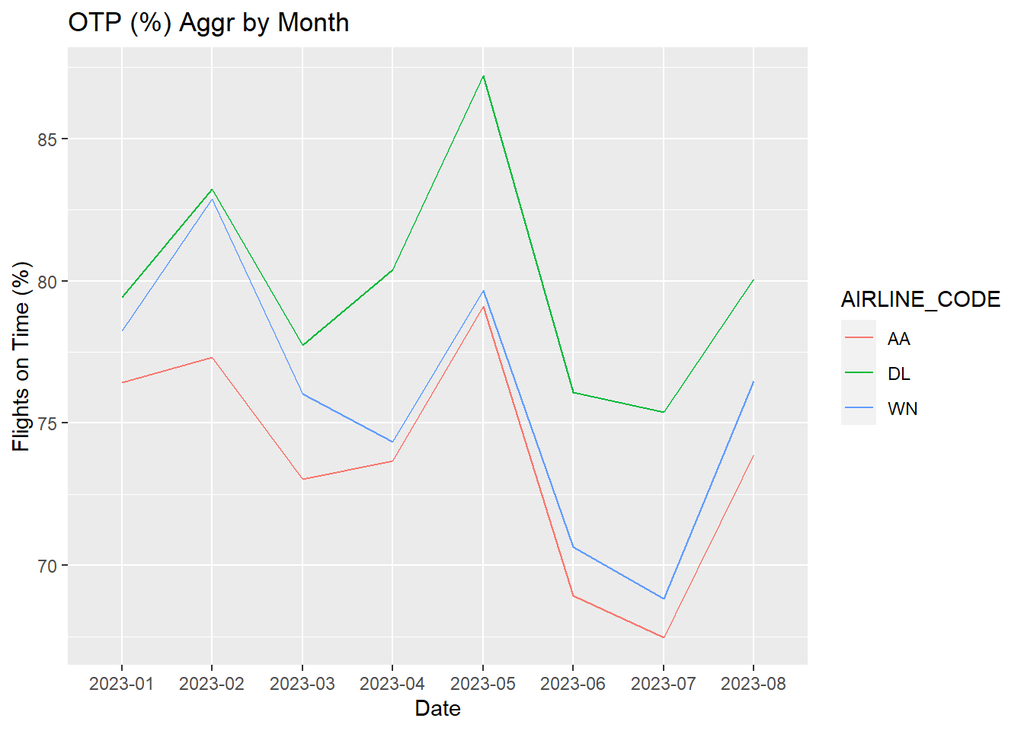

```r
ggplot(OTP, aes(x = FL_MONTH, y = OnTimePercent, group = AIRLINE_CODE, color = AIRLINE_CODE)) +
  geom_line() +
  labs(x = "Date", y = "Flights on Time (%)", title = "OTP (%) Aggr by Month")
```

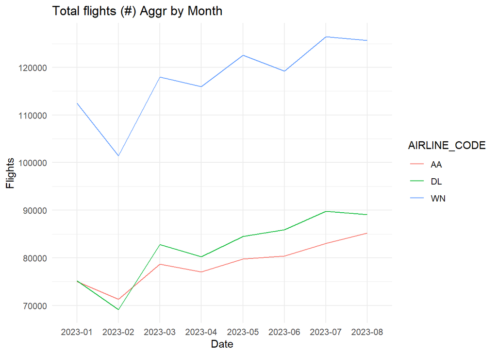

```r
#Number of flights
ggplot(OTP, aes(x = FL_MONTH, y = TotalFlights, group = AIRLINE_CODE, color = AIRLINE_CODE)) +
  geom_line() +
  labs(x = "Date", y = "Flights", title = "Total flights (#) Aggr by Month") +
  theme_minimal()
```

4. For the categorical variables, plot bar charts for the different values of `y`. Do you see a difference between plots for any of the variables you choose?

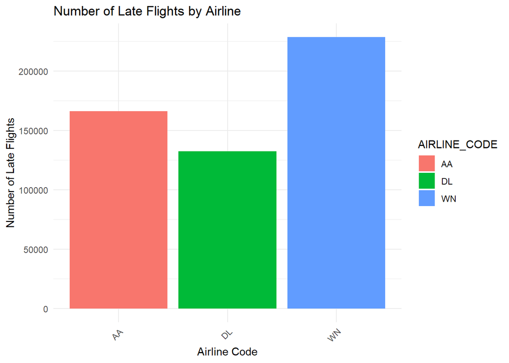

```r
#needs work


late_flights_by_airline <- df3 %>%
  filter(ontime == 0) %>%
  group_by(AIRLINE_CODE) %>%
  summarize(LateFlights = n())


ggplot(late_flights_by_airline, aes(x = AIRLINE_CODE, y = LateFlights, fill = AIRLINE_CODE)) +
  geom_bar(stat = "identity") +
  labs(x = "Airline Code", y = "Number of Late Flights", title = "Number of Late Flights by Airline") +
  theme_minimal() +
  theme(axis.text.x = element_text(angle = 45, hjust = 1))
```

5. Scale your **numeric** data using R function `scale()`, and combined these with your non-numeric data.
6. Test/training separation: Separate your data into 70% training and 30% testing data. Do not forget to set seed. Please use the same separation for the whole assignment, as it is needed to be able to compare the models.

```r
df3$AIRLINE_CODE <- as.factor(df3$AIRLINE_CODE)
df3$ontime<-as.factor(df3$ontime)


df3<- df3[, -which(names(df3) == "FL_YEAR")]

#Logistic Regression did not like the standard dataset, was under the assumption there were too many strings in dataset. Took out time related fields in df to eliminate some strings and added some more numeric values for log reg. to run.

df4<- data.frame(df3$AIRLINE_CODE,df3$AIR_TIME,df3$ontime,df3$TAXI_IN,df3$TAXI_OUT,df3$DELAY_DUE_CARRIER,df3$DELAY_DUE_LATE_AIRCRAFT, df3$DELAY_DUE_NAS,df3$DELAY_DUE_SECURITY)




head(df4)
```

```
##   df3.AIRLINE_CODE df3.AIR_TIME df3.ontime df3.TAXI_IN df3.TAXI_OUT
## 1               AA          302          1           4           20
## 2               AA          300          1           7           18
## 3               AA          304          1           9           17
## 4               AA          305          1           9           19
## 5               AA          311          1           8           18
## 6               AA          311          1          11           15
##   df3.DELAY_DUE_CARRIER df3.DELAY_DUE_LATE_AIRCRAFT df3.DELAY_DUE_NAS
## 1                     0                           0                 0
## 2                     0                           0                 0
## 3                     0                           0                 0
## 4                     0                           0                 0
## 5                     0                           0                 0
## 6                     0                           0                 0
##   df3.DELAY_DUE_SECURITY
## 1                      0
## 2                      0
## 3                      0
## 4                      0
## 5                      0
## 6                      0
```

```r
AA<- subset(df4,df4$df3.AIRLINE_CODE == 'AA' )
AA<- AA[, -which(names(AA) == "df3.AIRLINE_CODE")]
DL<- subset(df4,df4$df3.AIRLINE_CODE == 'DL')
DL<- DL[, -which(names(DL) == "df3.AIRLINE_CODE")]
WN<- subset(df4,df4$df3.AIRLINE_CODE == 'WN')
WN<- WN[, -which(names(WN) == "df3.AIRLINE_CODE")]


head(AA)
```

```
##   df3.AIR_TIME df3.ontime df3.TAXI_IN df3.TAXI_OUT df3.DELAY_DUE_CARRIER
## 1          302          1           4           20                     0
## 2          300          1           7           18                     0
## 3          304          1           9           17                     0
## 4          305          1           9           19                     0
## 5          311          1           8           18                     0
## 6          311          1          11           15                     0
##   df3.DELAY_DUE_LATE_AIRCRAFT df3.DELAY_DUE_NAS df3.DELAY_DUE_SECURITY
## 1                           0                 0                      0
## 2                           0                 0                      0
## 3                           0                 0                      0
## 4                           0                 0                      0
## 5                           0                 0                      0
## 6                           0                 0                      0
```

```r
head(DL)
```

```
##       df3.AIR_TIME df3.ontime df3.TAXI_IN df3.TAXI_OUT df3.DELAY_DUE_CARRIER
## 80417          270          1          18           10                     0
## 80418          262          1          16           11                     0
## 80419          258          1           8           16                     0
## 80420          268          1          14           16                     0
## 80421          108          1          11           10                     0
## 80422          108          1          12           15                     0
##       df3.DELAY_DUE_LATE_AIRCRAFT df3.DELAY_DUE_NAS df3.DELAY_DUE_SECURITY
## 80417                           0                 0                      0
## 80418                           0                 0                      0
## 80419                           0                 0                      0
## 80420                           0                 0                      0
## 80421                           0                 0                      0
## 80422                           0                 0                      0
```

```r
#Could have pursued this in two directions. Create training then subset by airline code, this will provide me a consistent 70% of Training data for each air line. If completed in reverse, the sample training data will be thrown off. Too many observations for logistic Regression to run on, which is the reason why the GLM will be ran 3 times.

set.seed(100)
indexAA = sample(1:nrow(AA),round(.7*nrow(AA)))
trainAA = AA[indexAA,]
testAA = AA[-indexAA,]

set.seed(100)
indexDL = sample(1:nrow(DL),round(.7*nrow(DL)))
trainDL = DL[indexDL,]
testDL = DL[-indexDL,]

set.seed(100)
indexWN = sample(1:nrow(WN),round(.7*nrow(WN)))
trainWN = WN[indexWN,]
testWN = WN[-indexWN,]

#apply(df4,2,function(x) sum(is.na(x)))



#na.omit(df4)
```

## Part 2: Logistic Regression (15 points)

1. Develop a classification model where the variable `y` is the dependent variable using the Logistic Regression method, rest of the variables, and your training data set.

```r
valuectAA<-sapply(lapply(trainAA,unique),length)
valuectDL<-sapply(lapply(trainDL,unique),length)
valuectWN<-sapply(lapply(trainWN,unique),length)

#Since Airline was subseted, only one value presented, need more than two levels in data. Removing Airline code from df


valuectAA
```

```
##                df3.AIR_TIME                  df3.ontime
##                         490                           2
##                 df3.TAXI_IN                df3.TAXI_OUT
##                         147                         175
##       df3.DELAY_DUE_CARRIER df3.DELAY_DUE_LATE_AIRCRAFT
##                        1177                        1060
##           df3.DELAY_DUE_NAS      df3.DELAY_DUE_SECURITY
##                         340                          93
```

```r
valuectDL
```

```
##                df3.AIR_TIME                  df3.ontime
##                         637                           2
##                 df3.TAXI_IN                df3.TAXI_OUT
##                         161                         171
##       df3.DELAY_DUE_CARRIER df3.DELAY_DUE_LATE_AIRCRAFT
##                         965                         480
##           df3.DELAY_DUE_NAS      df3.DELAY_DUE_SECURITY
##                         362                          61
```

```r
valuectWN
```

```
##                df3.AIR_TIME                  df3.ontime
##                         404                           2
##                 df3.TAXI_IN                df3.TAXI_OUT
##                         135                         156
##       df3.DELAY_DUE_CARRIER df3.DELAY_DUE_LATE_AIRCRAFT
##                         382                         396
##           df3.DELAY_DUE_NAS      df3.DELAY_DUE_SECURITY
##                         317                         106
```

```r
levels(trainAA$df3.ontime)
```

```
## [1] "0" "1"
```

```r
OTPAA<- glm(trainAA$df3.ontime ~ . , family = 'binomial'  ,trainAA)
OTPDL<- glm(trainDL$df3.ontime ~ . , family = 'binomial'  ,trainDL)
OTPWN<- glm(trainWN$df3.ontime ~ . , family = 'binomial'  ,trainWN)
summary(OTPAA)
```

```
##
## Call:
## glm(formula = trainAA$df3.ontime ~ ., family = "binomial", data = trainAA)
##
## Coefficients:
##                               Estimate Std. Error  z value Pr(>|z|)
## (Intercept)                  5.4348968  0.0631652   86.043  < 2e-16 ***
## df3.AIR_TIME                 0.0007682  0.0002305    3.333 0.000858 ***
## df3.TAXI_IN                  0.0098771  0.0025905    3.813 0.000137 ***
## df3.TAXI_OUT                -0.0177454  0.0022835   -7.771 7.77e-15 ***
## df3.DELAY_DUE_CARRIER       -0.4147669  0.0029076 -142.648  < 2e-16 ***
## df3.DELAY_DUE_LATE_AIRCRAFT -0.4422750  0.0032712 -135.203  < 2e-16 ***
## df3.DELAY_DUE_NAS           -0.4319587  0.0031368 -137.706  < 2e-16 ***
## df3.DELAY_DUE_SECURITY      -0.4381602  0.0258639  -16.941  < 2e-16 ***
## ---
## Signif. codes:  0 '***' 0.001 '**' 0.01 '*' 0.05 '.' 0.1 ' ' 1
##
## (Dispersion parameter for binomial family taken to be 1)
##
##     Null deviance: 489033  on 433759  degrees of freedom
## Residual deviance:  34551  on 433752  degrees of freedom
##   (7520 observations deleted due to missingness)
## AIC: 34567
##
## Number of Fisher Scoring iterations: 11
```

```r
summary(OTPDL)
```

```
##
## Call:
## glm(formula = trainDL$df3.ontime ~ ., family = "binomial", data = trainDL)
##
## Coefficients:
##                               Estimate Std. Error  z value Pr(>|z|)
## (Intercept)                  5.7424660  0.0587347   97.770  < 2e-16 ***
## df3.AIR_TIME                 0.0011765  0.0002241    5.249 1.53e-07 ***
## df3.TAXI_IN                  0.0041838  0.0027197    1.538    0.124
## df3.TAXI_OUT                -0.0204516  0.0022511   -9.085  < 2e-16 ***
## df3.DELAY_DUE_CARRIER       -0.4316256  0.0028255 -152.763  < 2e-16 ***
## df3.DELAY_DUE_LATE_AIRCRAFT -0.4476415  0.0035388 -126.494  < 2e-16 ***
## df3.DELAY_DUE_NAS           -0.4347429  0.0032920 -132.062  < 2e-16 ***
## df3.DELAY_DUE_SECURITY      -0.4169708  0.0689265   -6.050 1.45e-09 ***
## ---
## Signif. codes:  0 '***' 0.001 '**' 0.01 '*' 0.05 '.' 0.1 ' ' 1
##
## (Dispersion parameter for binomial family taken to be 1)
##
##     Null deviance: 436453  on 451802  degrees of freedom
## Residual deviance:  30958  on 451795  degrees of freedom
##   (7777 observations deleted due to missingness)
## AIC: 30974
##
## Number of Fisher Scoring iterations: 10
```

```r
summary(OTPWN)
```

```
##
## Call:
## glm(formula = trainWN$df3.ontime ~ ., family = "binomial", data = trainWN)
##
## Coefficients:
##                               Estimate Std. Error  z value Pr(>|z|)
## (Intercept)                  7.1520914  0.0669760  106.786  < 2e-16 ***
## df3.AIR_TIME                -0.0003407  0.0002743   -1.242    0.214
## df3.TAXI_IN                 -0.0013742  0.0029912   -0.459    0.646
## df3.TAXI_OUT                -0.0122280  0.0025581   -4.780 1.75e-06 ***
## df3.DELAY_DUE_CARRIER       -0.5051009  0.0031502 -160.339  < 2e-16 ***
## df3.DELAY_DUE_LATE_AIRCRAFT -0.5216800  0.0030883 -168.921  < 2e-16 ***
## df3.DELAY_DUE_NAS           -0.5058920  0.0037177 -136.076  < 2e-16 ***
## df3.DELAY_DUE_SECURITY      -0.5044042  0.0148535  -33.959  < 2e-16 ***
## ---
## Signif. codes:  0 '***' 0.001 '**' 0.01 '*' 0.05 '.' 0.1 ' ' 1
##
## (Dispersion parameter for binomial family taken to be 1)
##
##     Null deviance: 701176  on 648988  degrees of freedom
## Residual deviance:  34664  on 648981  degrees of freedom
##   (10224 observations deleted due to missingness)
## AIC: 34680
##
## Number of Fisher Scoring iterations: 11
```

2. Take out all insignificant variables (at $\alpha=0.1$), and run the logistic model again.
3. Obtain the confusion matrix and compute the **testing error rate** based on the logistic regression classification.
4. Do you believe logistic regression did a good job here?

## Part 3: KNN (15 points)

1. Apply a KNN classification to the training data using k=5. Remember to create labels.
2. Obtain the confusion matrix and compute the testing error rate based on the KNN classification.
3. Do you believe knn classifier did a good job here?

## Part 4: Tree Based Model (15 points)

1. Apply one of the following models to your training data: *Classification Tree, Random Forrest, Bagging or Boosting*
2. Obtain the confusion matrix and compute the testing error rate based on your chosen tree based model.
3. Do you believe the tree based model did a good job here?

## Part 5: SVM or NN (15 points)

1. Apply one of the following models to your training data: *SVM or neural network*.
2. Calculate the confusion matrix using the testing data.
3. Do you believe your chosen model did a good job here?

## Part 6: Conclusion (20 points)

1. Based on the four classification models, which one do you think is the best model to predict `y`? Please consider the following in your response:
   - Accuracy/error rates
   - Do you think you can improve the model by adding any other information?
2. What are your learning outcomes for this assignment? Please focus on your learning outcomes in terms of predcitive analytics, model interpretations, and R skills.

## Part 7: Presentation (VIDEO) (20 points)

Give a 20 min presentation of your work, make sure everyone on the team speaks.